# Homework #3 technical component

The CDC Social Vulnerability Index (SVI) takes multiple differen population-level inputs (e.g., % of the population living in poverty, % of the population without health insurance) to identify particularly vulnerable counties. While the CDC SVI scores rely on adding up the percentiles of various characteristics, there are alternative indexes (e.g., [University of South Carolina SoVI index](https://sc.edu/study/colleges_schools/artsandsciences/centers_and_institutes/hvri/data_and_resources/sovi/index.php)) that use methods like PCA. Here, we are going to use the CDC SVI data to create an alternative index based on PCA.

```r
rm(list=ls())
knitr::opts_knit$set(root.dir = "C:\\Users\\jgluckman\\OneDrive - RAND Corporation\\Desktop\\Machine Learning\\\\PRGS-Intro-to-ML-2025\\")
setwd("C:\\Users\\jgluckman\\OneDrive - RAND Corporation\\Desktop\\Machine Learning\\\\PRGS-Intro-to-ML-2025\\")
pacman::p_load("tidyverse", "sf")
svi <- read.csv("data\\processed\\SVI Updated.csv")
svi_raw <- svi
```

1. The following variables are used in the SVI: `EP_POV150, EP_UNEMP, EP_HBURD, EP_NOHSDP, EP_UNINSUR, EP_AGE65, EP_AGE17, EP_DISABL, EP_SNGPNT, EP_LIMENG, EP_MINRTY, EP_MUNIT, EP_MOBILE, EP_CROWD, EP_NOVEH, EP_GROUPQ, EP_NOINT`
   1. Subset the merged dataset to only include the variables above and look at the pattern of missing data. Are missing observations scattered throughout the data or are entire rows or columns missing?

```r
keep <- c("EP_POV150", "EP_UNEMP", "EP_HBURD", "EP_NOHSDP", "EP_UNINSUR", "EP_AGE65", "EP_AGE17", "EP_DISABL", "EP_SNGPNT", "EP_LIMENG", "EP_MINRTY", "EP_MUNIT", "EP_MOBILE", "EP_CROWD", "EP_NOVEH", "EP_GROUPQ", "EP_NOINT")
svi <- svi[keep]
for(i in 1:ncol(svi)){
    print(summary(svi[i]))
}
```

```
   EP_POV150
 Min.   : 2.60
 1st Qu.:18.00
 Median :23.00
 Mean   :23.95
 3rd Qu.:28.90
 Max.   :66.60
 NA's   :96
    EP_UNEMP
 Min.   : 0.000
 1st Qu.: 3.400
 Median : 4.700
 Mean   : 4.951
 3rd Qu.: 6.000
 Max.   :32.000
 NA's   :96
    EP_HBURD
 Min.   : 0.00
 1st Qu.:18.60
 Median :21.55
 Mean   :21.86
 3rd Qu.:24.90
 Max.   :48.50
 NA's   :96
   EP_NOHSDP
 Min.   : 0.30
 1st Qu.: 7.50
 Median :10.45
 Mean   :11.65
 3rd Qu.:14.70
 Max.   :66.70
 NA's   :96
   EP_UNINSUR
 Min.   : 0.000
 1st Qu.: 5.800
 Median : 8.400
 Mean   : 9.513
 3rd Qu.:12.000
 Max.   :45.100
 NA's   :96
```

[output cut: 81 more lines]

```
 Min.   : 0.000
 1st Qu.: 1.200
 Median : 2.000
 Mean   : 3.469
 3rd Qu.: 3.900
 Max.   :43.000
 NA's   :96
    EP_NOINT
 Min.   : 0.00
 1st Qu.:12.30
 Median :16.10
 Mean   :17.22
 3rd Qu.:21.00
 Max.   :64.00
 NA's   :96
```

```r
head(svi)
```

```
  EP_POV150 EP_UNEMP EP_HBURD EP_NOHSDP EP_UNINSUR EP_AGE65 EP_AGE17 EP_DISABL
1      20.2      2.8     19.7       9.6        7.4     15.6     23.4      16.4
2      18.3      3.4     23.2       8.4        9.3     21.2     21.2      13.9
3      37.7      5.8     25.1      23.5       10.7     19.8     20.7      18.1
4      29.0      8.7     23.2      21.1        8.4     16.8     21.2      19.6
5      22.9      6.0     19.4      18.2       10.2     18.3     23.0      17.0
6      47.4      3.7     23.3      26.6       12.2     16.6     21.1      11.2
  EP_SNGPNT EP_LIMENG EP_MINRTY EP_MUNIT EP_MOBILE EP_CROWD EP_NOVEH EP_GROUPQ
1       5.6       0.4      27.4      3.9      15.6      1.4      4.0       0.9
2       4.2       0.8      17.7     16.6      10.2      1.9      2.3       1.5
3      11.3       2.0      55.4      1.4      29.2      3.8     11.7      12.0
4       7.2       0.3      25.8      2.7      30.6      1.3      7.5       6.4
5       5.3       2.2      14.3      0.9      23.9      2.3      4.8       1.0
6      16.3       1.8      79.4      4.1      42.4      0.8     10.4       7.1
  EP_NOINT
1     10.9
2     10.9
3     31.8
4     20.2
5     16.9
6     38.4
```

```
b. PCA cannot handle missing values by default.
There are several options for handling missing data generally, including imputation, removing rows with missing data, or removing columns with missing data.
Deal with the missing data in a way that makes sense for the pattern of missing data and the goals of the analysis. Explain why you made this decision.
_Note: How you handle this is specific to the missing data pattern and the goals of the analysis.
For example, when entire rows or columns are missing, imputation may not be appropriate and dropping those rows or columns is usually the best option.
Conversely, if you have a general missingness pattern where missing observations are scattered throughout the data, imputation is likely the best option._
```

Per my conversation with Gabe, this question was based on the completed data from Homework 2, which had its missing data cleaned.

```r
sapply(svi, function(x) sum(is.na(x)))
```

```
 EP_POV150   EP_UNEMP   EP_HBURD  EP_NOHSDP EP_UNINSUR   EP_AGE65   EP_AGE17
        96         96         96         96         96         96         96
 EP_DISABL  EP_SNGPNT  EP_LIMENG  EP_MINRTY   EP_MUNIT  EP_MOBILE   EP_CROWD
        96         96         96         96         96         96         96
  EP_NOVEH  EP_GROUPQ   EP_NOINT
        96         96         96
```

96 rows have missing data. I’ll remove those.

```r
svi <- svi[!is.na(svi$EP_POV150),]
```

```
a. After dealing with the missing data, perform PCA on the SVI variables.
```

```r
svi.std <- scale(svi)
pc.svi <- princomp(svi.std)
loadings <- pc.svi$loadings
loadings <- as.data.frame.table(loadings)
loadings <- loadings %>%
    pivot_wider(names_from = Var2, values_from = Freq)
cats <- loadings$Var1
rownames(loadings) <- cats
loadings$Var1 <- NULL
pcnames <- NA
for(i in 1:ncol(loadings)){
    pcnames[i] <- paste("PC", i, sep = "")
}
names(loadings) <- pcnames
rownames(loadings) <- cats
head(loadings)
```

```
# A tibble: 6 × 17
     PC1      PC2     PC3       PC4      PC5     PC6      PC7     PC8      PC9
   <dbl>    <dbl>   <dbl>     <dbl>    <dbl>   <dbl>    <dbl>   <dbl>    <dbl>
1  0.368  0.189    0.108   0.119     0.0540  0.0988   0.172    0.0526  0.0976
2  0.278  0.0435   0.270   0.270    -0.0846  0.00254 -0.638   -0.139  -0.162
3  0.139 -0.169    0.460   0.000493  0.0152  0.483    0.154   -0.199   0.214
4  0.368  0.0928  -0.140  -0.229    -0.00578 0.0948  -0.00877  0.420   0.00511
5  0.293 -0.00392 -0.281  -0.208    -0.102   0.0345   0.248   -0.566   0.193
6 -0.145  0.375    0.0989 -0.127    -0.474   0.0913   0.0735  -0.198  -0.358
# ℹ 8 more variables: PC10 <dbl>, PC11 <dbl>, PC12 <dbl>, PC13 <dbl>,
#   PC14 <dbl>, PC15 <dbl>, PC16 <dbl>, PC17 <dbl>
```

1. Plot the eigenvectors or loadings associated of the first three principal components. Make sure that the axis labels correspond to the variable names and not the indices of the variables. How would you interpret the first three prinicpal components? *Note: you can find the documentation for the SVI variables [here](https://www.atsdr.cdc.gov/placeandhealth/svi/documentation/SVI_documentation_2022.html).*

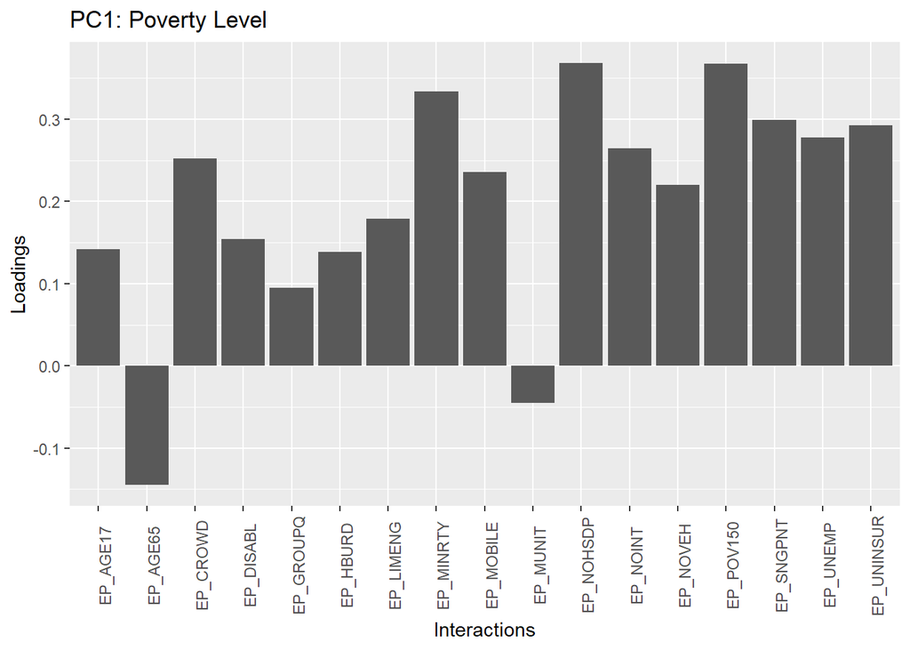

```r
print(ggplot(data = loadings) +
geom_bar(aes(x = rownames(loadings), y = PC1), stat = "identity") +
labs(title = "PC1: Poverty Level", x = "Interactions", y = "Loadings") +
theme(axis.text.x = element_text(angle = 90)))
```